# Fraud Detection

```python
import pandas as pd
import numpy as np
import matplotlib.pyplot as plt
%matplotlib inline
import seaborn as sns
import warnings
warnings.filterwarnings('ignore')
```

```python
# Reading data
data = pd .read_csv("Fraud.csv")
data
```

|  | step | type | amount | nameOrig | oldbalanceOrg | newbalanceOrig | nameDest | oldbalanceDest | newbalanceDest | isFraud | isFlaggedFraud |
| --- | --- | --- | --- | --- | --- | --- | --- | --- | --- | --- | --- |
| 0 | 1 | PAYMENT | 9839.64 | C1231006815 | 170136.00 | 160296.36 | M1979787155 | 0.00 | 0.00 | 0 | 0 |
| 1 | 1 | PAYMENT | 1864.28 | C1666544295 | 21249.00 | 19384.72 | M2044282225 | 0.00 | 0.00 | 0 | 0 |
| 2 | 1 | TRANSFER | 181.00 | C1305486145 | 181.00 | 0.00 | C553264065 | 0.00 | 0.00 | 1 | 0 |
| 3 | 1 | CASH_OUT | 181.00 | C840083671 | 181.00 | 0.00 | C38997010 | 21182.00 | 0.00 | 1 | 0 |
| 4 | 1 | PAYMENT | 11668.14 | C2048537720 | 41554.00 | 29885.86 | M1230701703 | 0.00 | 0.00 | 0 | 0 |
| ... | ... | ... | ... | ... | ... | ... | ... | ... | ... | ... | ... |
| 6362615 | 743 | CASH_OUT | 339682.13 | C786484425 | 339682.13 | 0.00 | C776919290 | 0.00 | 339682.13 | 1 | 0 |
| 6362616 | 743 | TRANSFER | 6311409.28 | C1529008245 | 6311409.28 | 0.00 | C1881841831 | 0.00 | 0.00 | 1 | 0 |
| 6362617 | 743 | CASH_OUT | 6311409.28 | C1162922333 | 6311409.28 | 0.00 | C1365125890 | 68488.84 | 6379898.11 | 1 | 0 |
| 6362618 | 743 | TRANSFER | 850002.52 | C1685995037 | 850002.52 | 0.00 | C2080388513 | 0.00 | 0.00 | 1 | 0 |
| 6362619 | 743 | CASH_OUT | 850002.52 | C1280323807 | 850002.52 | 0.00 | C873221189 | 6510099.11 | 7360101.63 | 1 | 0 |

6362620 rows × 11 columns

```python
# printing the head of data frame
data.head()
```

|  | step | type | amount | nameOrig | oldbalanceOrg | newbalanceOrig | nameDest | oldbalanceDest | newbalanceDest | isFraud | isFlaggedFraud |
| --- | --- | --- | --- | --- | --- | --- | --- | --- | --- | --- | --- |
| 0 | 1 | PAYMENT | 9839.64 | C1231006815 | 170136.0 | 160296.36 | M1979787155 | 0.0 | 0.0 | 0 | 0 |
| 1 | 1 | PAYMENT | 1864.28 | C1666544295 | 21249.0 | 19384.72 | M2044282225 | 0.0 | 0.0 | 0 | 0 |
| 2 | 1 | TRANSFER | 181.00 | C1305486145 | 181.0 | 0.00 | C553264065 | 0.0 | 0.0 | 1 | 0 |
| 3 | 1 | CASH_OUT | 181.00 | C840083671 | 181.0 | 0.00 | C38997010 | 21182.0 | 0.0 | 1 | 0 |
| 4 | 1 | PAYMENT | 11668.14 | C2048537720 | 41554.0 | 29885.86 | M1230701703 | 0.0 | 0.0 | 0 | 0 |

```python
# To check bottom five rows
data.tail()
```

|  | step | type | amount | nameOrig | oldbalanceOrg | newbalanceOrig | nameDest | oldbalanceDest | newbalanceDest | isFraud | isFlaggedFraud |
| --- | --- | --- | --- | --- | --- | --- | --- | --- | --- | --- | --- |
| 6362615 | 743 | CASH_OUT | 339682.13 | C786484425 | 339682.13 | 0.0 | C776919290 | 0.00 | 339682.13 | 1 | 0 |
| 6362616 | 743 | TRANSFER | 6311409.28 | C1529008245 | 6311409.28 | 0.0 | C1881841831 | 0.00 | 0.00 | 1 | 0 |
| 6362617 | 743 | CASH_OUT | 6311409.28 | C1162922333 | 6311409.28 | 0.0 | C1365125890 | 68488.84 | 6379898.11 | 1 | 0 |
| 6362618 | 743 | TRANSFER | 850002.52 | C1685995037 | 850002.52 | 0.0 | C2080388513 | 0.00 | 0.00 | 1 | 0 |
| 6362619 | 743 | CASH_OUT | 850002.52 | C1280323807 | 850002.52 | 0.0 | C873221189 | 6510099.11 | 7360101.63 | 1 | 0 |

```python
# Here is the row count and type of each column
data.info()
```

```
<class 'pandas.core.frame.DataFrame'>
RangeIndex: 6362620 entries, 0 to 6362619
Data columns (total 11 columns):
 #   Column          Dtype
---  ------          -----
 0   step            int64
 1   type            object
 2   amount          float64
 3   nameOrig        object
 4   oldbalanceOrg   float64
 5   newbalanceOrig  float64
 6   nameDest        object
 7   oldbalanceDest  float64
 8   newbalanceDest  float64
 9   isFraud         int64
 10  isFlaggedFraud  int64
dtypes: float64(5), int64(3), object(3)
memory usage: 534.0+ MB
```

```python
# To check the dimension
data.shape
```

```
(6362620, 11)
```

```python
# To check columns
data.columns.tolist()
```

```
['step',
 'type',
 'amount',
 'nameOrig',
 'oldbalanceOrg',
 'newbalanceOrig',
 'nameDest',
 'oldbalanceDest',
 'newbalanceDest',
 'isFraud',
 'isFlaggedFraud']
```

```python
# To check columns types
data.dtypes
```

```
step                int64
type               object
amount            float64
nameOrig           object
oldbalanceOrg     float64
newbalanceOrig    float64
nameDest           object
oldbalanceDest    float64
newbalanceDest    float64
isFraud             int64
isFlaggedFraud      int64
dtype: object
```

```python
# To check no. of unique value in each column
data.nunique()
```

```
step                  743
type                    5
amount            5316900
nameOrig          6353307
oldbalanceOrg     1845844
newbalanceOrig    2682586
nameDest          2722362
oldbalanceDest    3614697
newbalanceDest    3555499
isFraud                 2
isFlaggedFraud          2
dtype: int64
```

```python
# checking for missing values in our dataset
data.isnull().sum()
```

```
step              0
type              0
amount            0
nameOrig          0
oldbalanceOrg     0
newbalanceOrig    0
nameDest          0
oldbalanceDest    0
newbalanceDest    0
isFraud           0
isFlaggedFraud    0
dtype: int64
```

```python
# To check duplicates
data.duplicated().sum()
```

```
0
```

```python
data.describe()
```

|  | step | amount | oldbalanceOrg | newbalanceOrig | oldbalanceDest | newbalanceDest | isFraud | isFlaggedFraud |
| --- | --- | --- | --- | --- | --- | --- | --- | --- |
| count | 6.362620e+06 | 6.362620e+06 | 6.362620e+06 | 6.362620e+06 | 6.362620e+06 | 6.362620e+06 | 6.362620e+06 | 6.362620e+06 |
| mean | 2.433972e+02 | 1.798619e+05 | 8.338831e+05 | 8.551137e+05 | 1.100702e+06 | 1.224996e+06 | 1.290820e-03 | 2.514687e-06 |
| std | 1.423320e+02 | 6.038582e+05 | 2.888243e+06 | 2.924049e+06 | 3.399180e+06 | 3.674129e+06 | 3.590480e-02 | 1.585775e-03 |
| min | 1.000000e+00 | 0.000000e+00 | 0.000000e+00 | 0.000000e+00 | 0.000000e+00 | 0.000000e+00 | 0.000000e+00 | 0.000000e+00 |
| 25% | 1.560000e+02 | 1.338957e+04 | 0.000000e+00 | 0.000000e+00 | 0.000000e+00 | 0.000000e+00 | 0.000000e+00 | 0.000000e+00 |
| 50% | 2.390000e+02 | 7.487194e+04 | 1.420800e+04 | 0.000000e+00 | 1.327057e+05 | 2.146614e+05 | 0.000000e+00 | 0.000000e+00 |
| 75% | 3.350000e+02 | 2.087215e+05 | 1.073152e+05 | 1.442584e+05 | 9.430367e+05 | 1.111909e+06 | 0.000000e+00 | 0.000000e+00 |
| max | 7.430000e+02 | 9.244552e+07 | 5.958504e+07 | 4.958504e+07 | 3.560159e+08 | 3.561793e+08 | 1.000000e+00 | 1.000000e+00 |

```python
data.corr()
```

|  | step | amount | oldbalanceOrg | newbalanceOrig | oldbalanceDest | newbalanceDest | isFraud | isFlaggedFraud |
| --- | --- | --- | --- | --- | --- | --- | --- | --- |
| step | 1.000000 | 0.022373 | -0.010058 | -0.010299 | 0.027665 | 0.025888 | 0.031578 | 0.003277 |
| amount | 0.022373 | 1.000000 | -0.002762 | -0.007861 | 0.294137 | 0.459304 | 0.076688 | 0.012295 |
| oldbalanceOrg | -0.010058 | -0.002762 | 1.000000 | 0.998803 | 0.066243 | 0.042029 | 0.010154 | 0.003835 |
| newbalanceOrig | -0.010299 | -0.007861 | 0.998803 | 1.000000 | 0.067812 | 0.041837 | -0.008148 | 0.003776 |
| oldbalanceDest | 0.027665 | 0.294137 | 0.066243 | 0.067812 | 1.000000 | 0.976569 | -0.005885 | -0.000513 |
| newbalanceDest | 0.025888 | 0.459304 | 0.042029 | 0.041837 | 0.976569 | 1.000000 | 0.000535 | -0.000529 |
| isFraud | 0.031578 | 0.076688 | 0.010154 | -0.008148 | -0.005885 | 0.000535 | 1.000000 | 0.044109 |
| isFlaggedFraud | 0.003277 | 0.012295 | 0.003835 | 0.003776 | -0.000513 | -0.000529 | 0.044109 | 1.000000 |

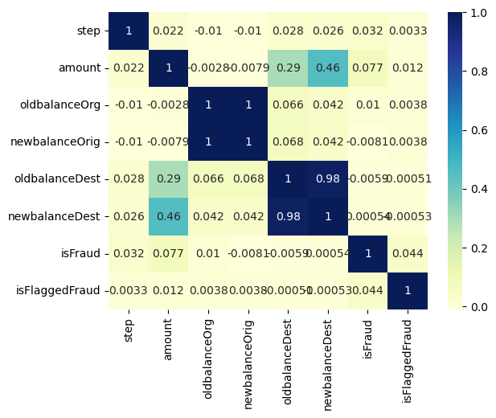

```python
sns.heatmap(data.corr(),cmap='YlGnBu',annot= True)
```

```python
legal = len(data[data.isFraud == 0])
fraud = len(data[data.isFraud == 1])
```

```python
legal_percent = (legal / (fraud + legal)) * 100
print("Number of Legal transactions: ", legal)
print(f"Percentage of Legal transactions: {legal_percent:.2f} %")
```

```
Number of Legal transactions:  6354407
Percentage of Legal transactions: 99.87 %
```

```python
fraud_percent = (fraud / (fraud + legal)) * 100
print("Number of Fraud transactions: ", fraud)
print(f"Percentage of Fraud transactions: {fraud_percent:.2f} %")
```

```
Number of Fraud transactions:  8213
Percentage of Fraud transactions: 0.13 %
```

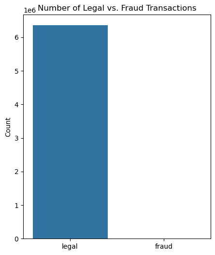

```python
plt.figure(figsize=(5, 6))
sns.barplot(x=['legal', 'fraud'], y=[legal, fraud])
plt.title('Number of Legal vs. Fraud Transactions')
plt.ylabel('Count')
plt.show()
```

```python
from sklearn import preprocessing
label = preprocessing.LabelEncoder()
data['type'] = label.fit_transform(data['type'])
data['nameOrig'] = label.fit_transform(data['nameOrig'])
data['nameDest'] = label.fit_transform(data['nameDest'])
```

```python
df = data
df
```

|  | step | type | amount | nameOrig | oldbalanceOrg | newbalanceOrig | nameDest | oldbalanceDest | newbalanceDest | isFraud | isFlaggedFraud |
| --- | --- | --- | --- | --- | --- | --- | --- | --- | --- | --- | --- |
| 0 | 1 | 3 | 9839.64 | 757869 | 170136.00 | 160296.36 | 1662094 | 0.00 | 0.00 | 0 | 0 |
| 1 | 1 | 3 | 1864.28 | 2188998 | 21249.00 | 19384.72 | 1733924 | 0.00 | 0.00 | 0 | 0 |
| 2 | 1 | 4 | 181.00 | 1002156 | 181.00 | 0.00 | 439685 | 0.00 | 0.00 | 1 | 0 |
| 3 | 1 | 1 | 181.00 | 5828262 | 181.00 | 0.00 | 391696 | 21182.00 | 0.00 | 1 | 0 |
| 4 | 1 | 3 | 11668.14 | 3445981 | 41554.00 | 29885.86 | 828919 | 0.00 | 0.00 | 0 | 0 |
| ... | ... | ... | ... | ... | ... | ... | ... | ... | ... | ... | ... |
| 6362615 | 743 | 1 | 339682.13 | 5651847 | 339682.13 | 0.00 | 505863 | 0.00 | 339682.13 | 1 | 0 |
| 6362616 | 743 | 4 | 6311409.28 | 1737278 | 6311409.28 | 0.00 | 260949 | 0.00 | 0.00 | 1 | 0 |
| 6362617 | 743 | 1 | 6311409.28 | 533958 | 6311409.28 | 0.00 | 108224 | 68488.84 | 6379898.11 | 1 | 0 |
| 6362618 | 743 | 4 | 850002.52 | 2252932 | 850002.52 | 0.00 | 319713 | 0.00 | 0.00 | 1 | 0 |
| 6362619 | 743 | 1 | 850002.52 | 919229 | 850002.52 | 0.00 | 534595 | 6510099.11 | 7360101.63 | 1 | 0 |

6362620 rows × 11 columns

```python
from statsmodels.stats.outliers_influence import variance_inflation_factor

def calc_vif(data):

    # Calculating VIF
    vif = pd.DataFrame()
    vif["variables"] = df.columns
    vif["VIF"] = [variance_inflation_factor(df.values, i) for i in range(df.shape[1])]

    return(vif)

calc_vif(df)
```

|  | variables | VIF |
| --- | --- | --- |
| 0 | step | 2.791610 |
| 1 | type | 4.467405 |
| 2 | amount | 4.149312 |
| 3 | nameOrig | 2.764234 |
| 4 | oldbalanceOrg | 576.803777 |
| 5 | newbalanceOrig | 582.709128 |
| 6 | nameDest | 3.300975 |
| 7 | oldbalanceDest | 73.349937 |
| 8 | newbalanceDest | 85.005614 |
| 9 | isFraud | 1.195305 |
| 10 | isFlaggedFraud | 1.002587 |

```python
df['Actual_amount_orig'] = df.apply(lambda x: x['oldbalanceOrg'] - x['newbalanceOrig'],axis=1)
df['Actual_amount_dest'] = df.apply(lambda x: x['oldbalanceDest'] - x['newbalanceDest'],axis=1)
df['TransactionPath'] = df.apply(lambda x: x['nameOrig'] + x['nameDest'],axis=1)

#Dropping columns
df = df.drop(['oldbalanceOrg','newbalanceOrig','oldbalanceDest','newbalanceDest','step','nameOrig','nameDest'],axis=1)

calc_vif(df)
```

|  | variables | VIF |
| --- | --- | --- |
| 0 | type | 2.687803 |
| 1 | amount | 3.818902 |
| 2 | isFraud | 1.184479 |
| 3 | isFlaggedFraud | 1.002546 |
| 4 | Actual_amount_orig | 1.307910 |
| 5 | Actual_amount_dest | 3.754335 |
| 6 | TransactionPath | 2.677167 |

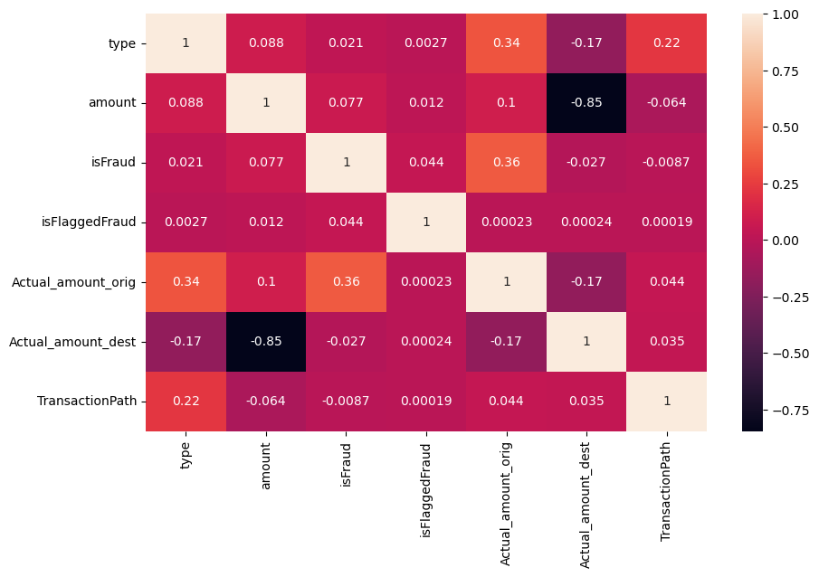

```python
corr=df.corr()

plt.figure(figsize=(10,6))
sns.heatmap(corr,annot=True)
```

```python
from sklearn.model_selection import train_test_split, cross_val_score
from sklearn.preprocessing import StandardScaler
from sklearn.tree import DecisionTreeClassifier
from sklearn.ensemble import RandomForestClassifier
import itertools
from collections import Counter
import sklearn.metrics as metrics
from sklearn.metrics import confusion_matrix, classification_report, roc_auc_score, roc_curve, precision_recall_curve, ConfusionMatrixDisplay
```

```python
# Perform Scaling
scaler = StandardScaler()
df["NormalizedAmount"] = scaler.fit_transform(df["amount"].values.reshape(-1, 1))
df.drop(["amount"], inplace= True, axis= 1)
X = df.drop(["isFraud"], axis= 1)
Y = df["isFraud"]
```

```python
(X_train, X_test, Y_train, Y_test) = train_test_split(X, Y, test_size= 0.3, random_state= 42)

print("Shape of X_train: ", X_train.shape)
print("Shape of X_test: ", X_test.shape)
```

```
Shape of X_train:  (4453834, 6)
Shape of X_test:  (1908786, 6)
```

```python
# DECISION TREE
decision_tree = DecisionTreeClassifier()
decision_tree.fit(X_train, Y_train)
Y_pred_dt = decision_tree.predict(X_test)
decision_tree_score = decision_tree.score(X_test, Y_test) * 100
print("Decision Tree Score: ", decision_tree_score)
```

```
Decision Tree Score:  99.9226209747976
```

```python
# RANDOM FOREST

random_forest = RandomForestClassifier(n_estimators= 100)
random_forest.fit(X_train, Y_train)
Y_pred_rf = random_forest.predict(X_test)
random_forest_score = random_forest.score(X_test, Y_test) * 100
print("Random Forest Score: ", random_forest_score)
```

```
Random Forest Score:  99.95866482675376
```

```python
# key terms of Confusion Matrix - DT

print("TP,FP,TN,FN - Decision Tree")
tn, fp, fn, tp = confusion_matrix(Y_test, Y_pred_dt).ravel()
print(f'True Positives: {tp}')
print(f'False Positives: {fp}')
print(f'True Negatives: {tn}')
print(f'False Negatives: {fn}')
```

```
TP,FP,TN,FN - Decision Tree
True Positives: 1720
False Positives: 762
True Negatives: 1905589
False Negatives: 715
```

```python
# confusion matrix - DT

confusion_matrix_dt = confusion_matrix(Y_test, Y_pred_dt.round())
print("Confusion Matrix - Decision Tree")
print(confusion_matrix_dt,)
```

```
Confusion Matrix - Decision Tree
[[1905589     762]
 [    715    1720]]
```

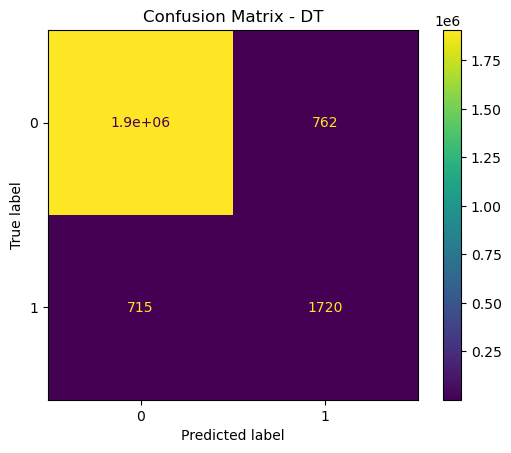

```python
# visualising confusion matrix - DT

disp = ConfusionMatrixDisplay(confusion_matrix=confusion_matrix_dt)
disp.plot()
plt.title('Confusion Matrix - DT')
plt.show()
```

```python
# key terms of Confusion Matrix - RF

print("TP,FP,TN,FN - Random Forest")
tn, fp, fn, tp = confusion_matrix(Y_test, Y_pred_rf).ravel()
print(f'True Positives: {tp}')
print(f'False Positives: {fp}')
print(f'True Negatives: {tn}')
print(f'False Negatives: {fn}')
```

```
TP,FP,TN,FN - Random Forest
True Positives: 1712
False Positives: 66
True Negatives: 1906285
False Negatives: 723
```

```python
# confusion matrix - RF

confusion_matrix_rf = confusion_matrix(Y_test, Y_pred_rf.round())
print("Confusion Matrix - Random Forest")
print(confusion_matrix_rf)
```

```
Confusion Matrix - Random Forest
[[1906285      66]
 [    723    1712]]
```

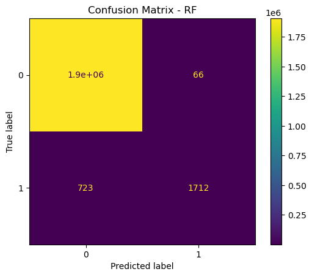

```python
# visualising confusion matrix - RF
disp = ConfusionMatrixDisplay(confusion_matrix=confusion_matrix_rf)
disp.plot()
plt.title('Confusion Matrix - RF')
plt.show()
```

```python
# classification report - DT

classification_report_dt = classification_report(Y_test, Y_pred_dt)
print("Classification Report - Decision Tree")
print(classification_report_dt)

# classification report - RF

classification_report_rf = classification_report(Y_test, Y_pred_rf)
print("Classification Report - Random Forest")
print(classification_report_rf)
```

```
Classification Report - Decision Tree
              precision    recall  f1-score   support

           0       1.00      1.00      1.00   1906351
           1       0.69      0.71      0.70      2435

    accuracy                           1.00   1908786
   macro avg       0.85      0.85      0.85   1908786
weighted avg       1.00      1.00      1.00   1908786

Classification Report - Random Forest
              precision    recall  f1-score   support

           0       1.00      1.00      1.00   1906351
           1       0.96      0.70      0.81      2435

    accuracy                           1.00   1908786
   macro avg       0.98      0.85      0.91   1908786
weighted avg       1.00      1.00      1.00   1908786
```

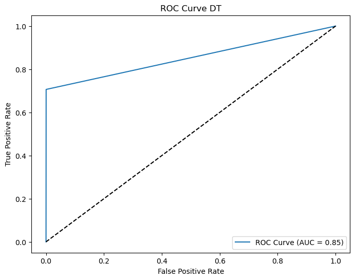

```python
# ROC Curve DT

fpr, tpr, threshold = roc_curve(Y_test, Y_pred_dt)
roc_auc = metrics.auc(fpr, tpr)
plt.figure(figsize=(8, 6))
plt.plot(fpr, tpr, label=f'ROC Curve (AUC = {roc_auc:.2f})')
plt.plot([0, 1], [0, 1], 'k--')
plt.xlabel('False Positive Rate')
plt.ylabel('True Positive Rate')
plt.title('ROC Curve DT')
plt.legend(loc='lower right')
plt.show()
```

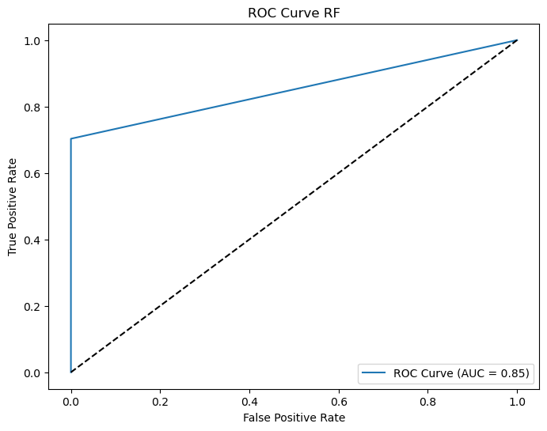

```python
# ROC Curve RF

fpr, tpr, threshold = roc_curve(Y_test, Y_pred_rf)
roc_auc = metrics.auc(fpr, tpr)
plt.figure(figsize=(8, 6))
plt.plot(fpr, tpr, label=f'ROC Curve (AUC = {roc_auc:.2f})')
plt.plot([0, 1], [0, 1], 'k--')
plt.xlabel('False Positive Rate')
plt.ylabel('True Positive Rate')
plt.title('ROC Curve RF')
plt.legend(loc='lower right')
plt.show()
```

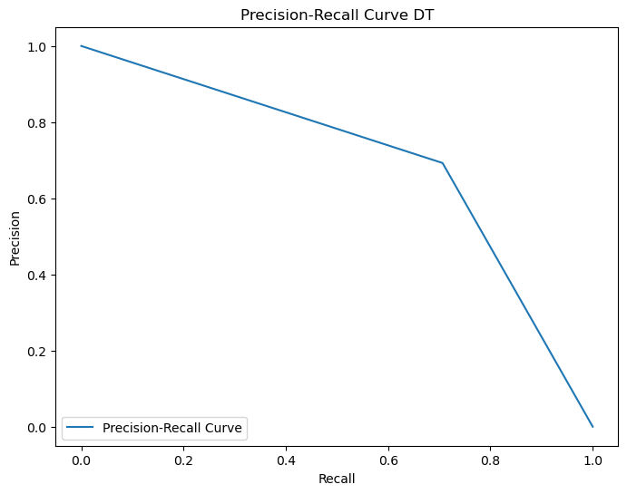

```python
# Precision-Recall Curve DT
precision, recall, _ = precision_recall_curve(Y_test, Y_pred_dt)
plt.figure(figsize=(8, 6))
plt.plot(recall, precision, label='Precision-Recall Curve')
plt.xlabel('Recall')
plt.ylabel('Precision')
plt.title('Precision-Recall Curve DT')
plt.legend(loc='lower left')
plt.show()
```

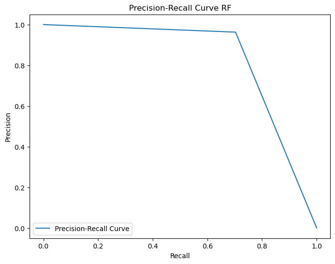

```python
# Precision-Recall Curve RF
precision, recall, _ = precision_recall_curve(Y_test, Y_pred_rf)
plt.figure(figsize=(8, 6))
plt.plot(recall, precision, label='Precision-Recall Curve')
plt.xlabel('Recall')
plt.ylabel('Precision')
plt.title('Precision-Recall Curve RF')
plt.legend(loc='lower left')
plt.show()
```

## Conclusion:

In the course of developing and evaluating a fraud detection model, several key observations and decisions have been made.

### Model Performance:

Both Random Forest and Decision Tree models were assessed for their performance in detecting fraudulent transactions. While the accuracy of both models was equal, it's crucial to prioritize precision in fraud detection models. Precision ensures that when a transaction is flagged as fraudulent, it's highly likely to be a true fraud, minimizing the risk of falsely accusing innocent customers. In this context, Random Forest showed higher precision, making it a preferred choice.

### Choice of Algorithms:

Random Forest and Decision Tree algorithms were selected due to their suitability for handling highly unbalanced datasets, which is common in fraud detection (99.87% legitimate transactions vs. 0.13% fraudulent transactions). Random Forest, in particular, creates multiple decision trees, simplifying the data's understanding while maintaining a balance between accuracy and precision.

### Key Factors for Fraud Prediction:

Several key factors were identified as important for predicting fraudulent customers:

1.Source of Request Security: Determining whether the source of a transaction request is secure or not is critical. Secure sources are less likely to be associated with fraudulent activity.

2.Legitimacy of the Requesting Organization: Verifying the legitimacy of the organization requesting a transaction is crucial. Illegitimate organizations are more likely to engage in fraudulent transactions.

3.Transaction History of Vendors: Analyzing the transaction history of vendors can provide insights into their legitimacy. Frequent associations with fraudulent transactions may indicate a higher risk.

### Prevention Strategies During Infrastructure Updates:

To enhance fraud prevention as the company updates its infrastructure, the following strategies are recommended:

1.Use Verified Apps Only: Encourage customers to use only verified and trusted applications to conduct financial transactions, reducing the risk of interacting with fraudulent apps.

2.Secure Browsing: Emphasize the importance of secure browsing habits. Customers should ensure they are visiting legitimate and secure websites for financial transactions.

3.Secure Internet Connections (VPN): Promote the use of Virtual Private Networks (VPNs) to secure internet connections, especially when accessing financial services remotely.

4.Device Security: Advise customers to keep their mobile devices and laptops updated with the latest security patches and antivirus software to prevent malware attacks.

5.Avoid Unsolicited Communications: Educate customers not to respond to unsolicited calls, SMS, or emails requesting sensitive financial information.

6.Immediate Contact with the Bank: If customers suspect that their security has been compromised or they have been tricked, encourage them to contact the bank immediately to report the issue and take necessary actions.

### Monitoring the Effectiveness of Prevention Measures:

To determine the effectiveness of these prevention measures, a proactive approach is essential:

1.E-Statements: Banks should actively send e-statements to customers, providing a detailed record of their account activity. Customers should review these statements regularly for any unauthorized transactions.

2.Customer Vigilance: Encourage customers to be vigilant and keep an eye on their account activity. Any unusual or suspicious transactions should be reported to the bank promptly.

3.Transaction Logs: Banks and customers should maintain transaction logs to track payments and detect any discrepancies.

#### By implementing these measures and actively involving both banks and customers in fraud prevention, the company can enhance its security infrastructure and reduce the risk of fraudulent activities. Continuous monitoring and adaptation of strategies will be essential to stay ahead of evolving fraud tactics.